# Feiyaw_FinalHomeworkCode_02

Feiya Wang

9/16/2019

## Homework 2

Introduction: This is the code for [Homework 02](https://fuzzyatelin.github.io/bioanth-stats/homework-02.html), on week 3 of AN597

> Every Saturday morning, at the same time, a primatologist goes and sits in the forest to listen for titi monkey calls, counting the number of calls they hear in a 2 hour window from 5am to 7am. Based on previous knowledge, she believes that the mean number of calls she will hear in that time is exactly 15. Let X represent the appropriate Poisson random variable of the number of calls heard in each monitoring session.

# Question 1

> What is the probability that she will hear more than 8 calls during any given session?

If her pervious belief is that she would hear 15 times calls in two hours at average, given a Possion distrubition, the probability that she should hear more than 8 calls is:

```r
x<-8
#calls she heard more than 8 time
aver<- 15
#average
prob<- ppois(x,lambda=aver)
#function for cumulative Probability of Possion distribution from 0 calls to 8 calls
prob<-1-prob
#subtracts the caslls from 0-8 times, left only the possibility of calls more than 8

prob
```

```
## [1] 0.9625535
```

## Question 2

> What is the probability that she will hear no calls in a session?

As above, the probability that she will hear no calls is that she would hears the calls that less than or equal to 0. Therefore, the probability is :

```r
x<-0
#calls she heard 0 times.
aver<- 15
#average
prob<- ppois(x,lambda=aver)
#function for cumulative Probability of Possion distribution.

prob
```

```
## [1] 3.059023e-07
```

# Question 3

> What is the probability that she will hear exactly 3 calls in a session?

same as above, using the similar function for x =3.

```r
x<-3
#calls she heard, exactly 3 times
aver<- 15
#average
prob<- dpois(x,lambda=aver)
#function for Probability of Possion distribution.


prob
```

```
## [1] 0.0001720701
```

# Question 4

> Plot the relevant Poisson mass function over the values in range 0 ≤ x ≤ 30.

seting the calls range from 0-30. Use barplot to draw the plot graph.

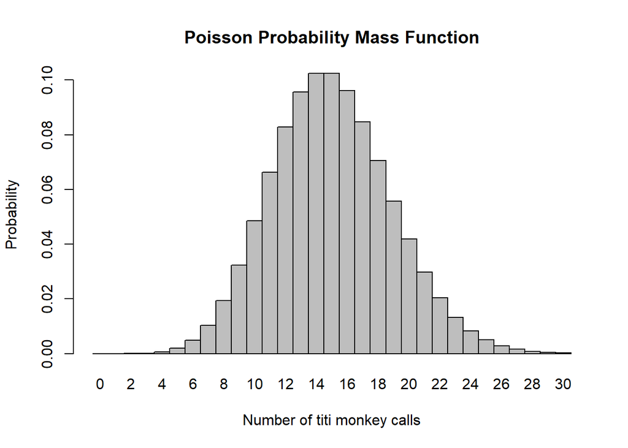

```r
x<-0:30
#Range
aver<- 15
#average
prob<- dpois(x,lambda=aver)
#function for Probability of Possion distribution.

barplot(prob,names.arg=x,space=0,xlab="Number of titi monkey calls",ylab="Probability",main="Poisson Probability Mass Function")
```